# AIML Module Project - Applied Statistics - Aaditya Kumar Ravi

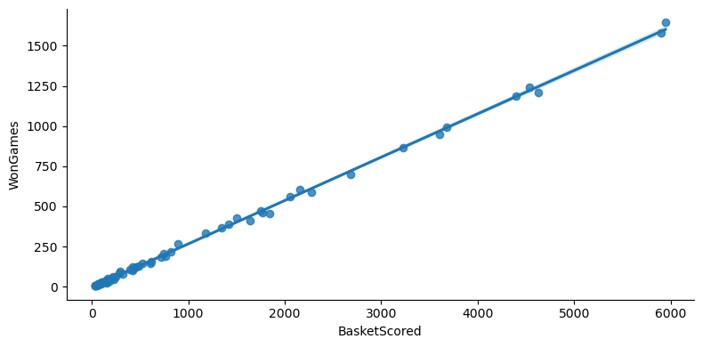

```python
sns.lmplot(data=data,x='BasketScored',y='WonGames',height=4,aspect=2)
plt.show()
```

- The more BasketScored, more WonGames which is obvious
- Shows strong positive corelation

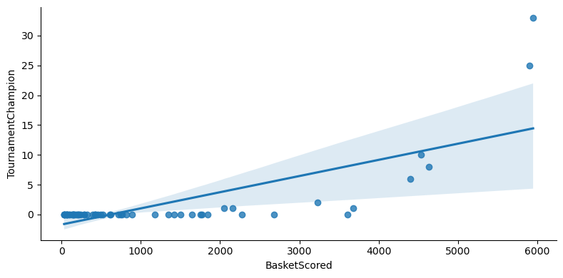

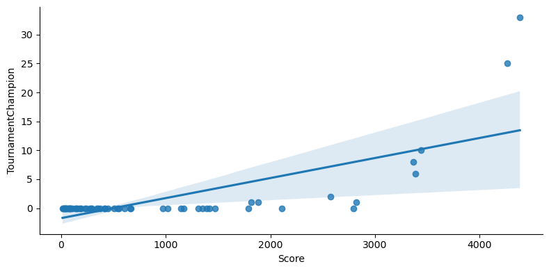

```python
sns.lmplot(data=data,x='BasketScored',y='TournamentChampion',height=4,aspect=2)
plt.show()

sns.lmplot(data=data,x='Score',y='TournamentChampion',height=4,aspect=2)
plt.show()
```

- Those who have high BasketScored, have become TournamentChamipion more times.
- Those who have high Score, have become TournamentChamipion more times.

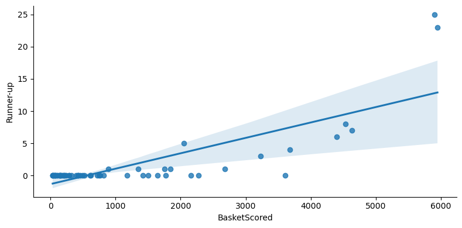

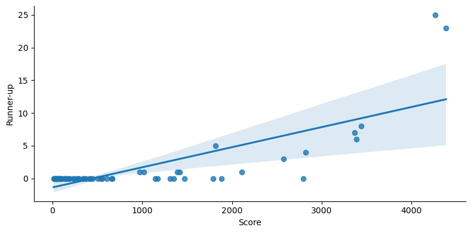

```python
sns.lmplot(data=data,x='BasketScored',y='Runner-up',height=4,aspect=2)
plt.show()

sns.lmplot(data=data,x='Score',y='Runner-up',height=4,aspect=2)
plt.show()
```

- Those who have high BasketScored, have become Runner-up more times.
- Those who have high Score, have become Runner-up more times.

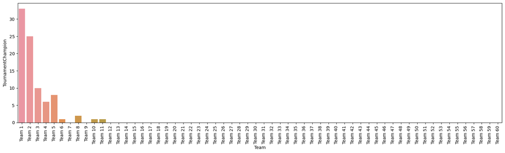

```python
plt.figure(figsize=(20,5))
sns.barplot(data=data,x='Team',y='TournamentChampion')
plt.xticks(rotation=90)
plt.show()
```

- Team 1 has highest Tournament Championship and then Team 2

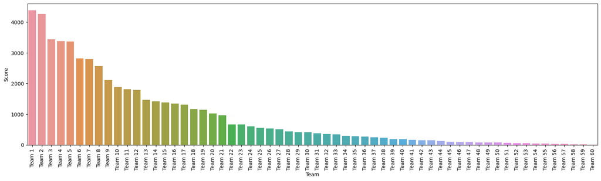

```python
plt.figure(figsize=(20,5))
sns.barplot(data=data,x='Team',y='Score')
plt.xticks(rotation=90)
plt.show()
```

- Team 1 has the highest score and Team 60 has the least score

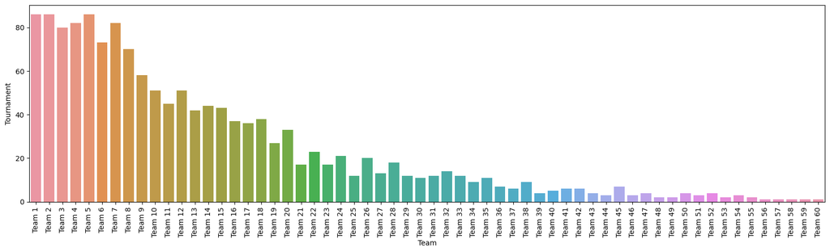

```python
plt.figure(figsize=(20,5))
sns.barplot(data=data,x='Team',y='Tournament')
plt.xticks(rotation=90)
plt.show()
```

- Team1,2 and Team 5 has highest number of tournaments played 86

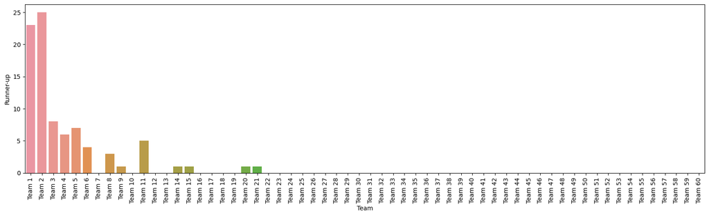

```python
plt.figure(figsize=(20,5))
sns.barplot(data=data,x='Team',y='Runner-up')
plt.xticks(rotation=90)
plt.show()
```

- Team 2 was runner up for highest number of times and then Team 1

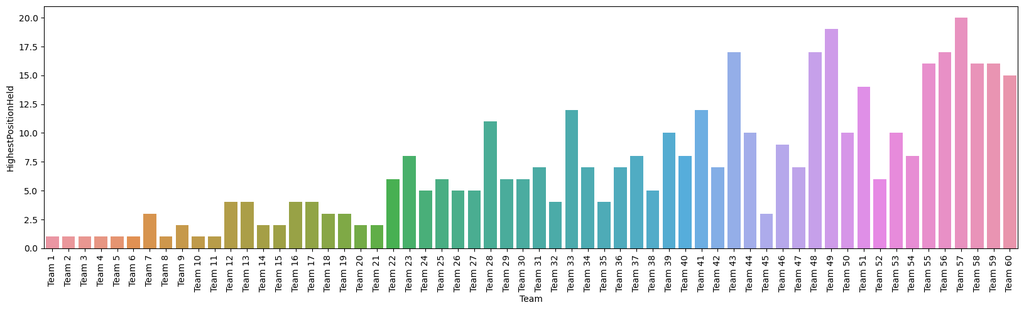

```python
plt.figure(figsize=(20,5))
sns.barplot(data=data,x='Team',y='HighestPositionHeld')
plt.xticks(rotation=90)
plt.show()
```

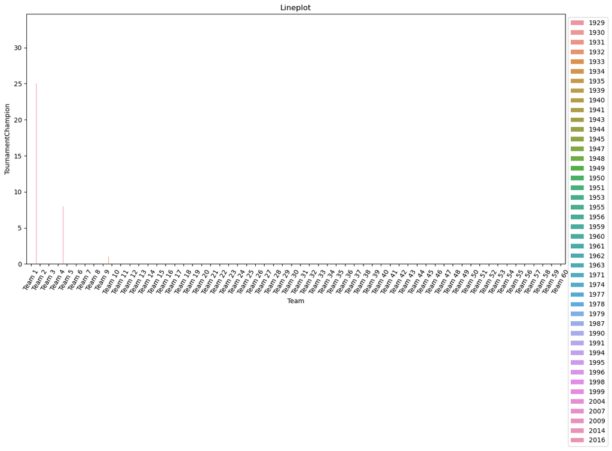

```python
plt.figure(figsize=(15,7))
plt.title("Lineplot")
sns.barplot(data=data, x='Team', y='TournamentChampion', hue="TeamLaunchStartYear")
plt.ylabel("TournamentChampion")
plt.xlabel("Team");
plt.xticks(rotation=60)
plt.legend(bbox_to_anchor=[1,1]);
```

```python
data.loc[(data['TeamLaunchStartYear']==1929) & (data['TournamentChampion']>1)]
```

|  | Team | Tournament | Score | PlayedGames | WonGames | DrawnGames | LostGames | BasketScored | BasketGiven | TournamentChampion | Runner-up | HighestPositionHeld | TeamLaunchStartYear | TeamLaunchEndYear |
| --- | --- | --- | --- | --- | --- | --- | --- | --- | --- | --- | --- | --- | --- | --- |
| 0 | Team 1 | 86 | 4385 | 2762 | 1647 | 552 | 563 | 5947 | 3140 | 33 | 23 | 1 | 1929 | 1929 |
| 1 | Team 2 | 86 | 4262 | 2762 | 1581 | 573 | 608 | 5900 | 3114 | 25 | 25 | 1 | 1929 | 1929 |
| 2 | Team 3 | 80 | 3442 | 2614 | 1241 | 598 | 775 | 4534 | 3309 | 10 | 8 | 1 | 1929 | 1929 |
| 4 | Team 5 | 86 | 3368 | 2762 | 1209 | 633 | 920 | 4631 | 3700 | 8 | 7 | 1 | 1929 | 1929 |
| 7 | Team 8 | 70 | 2573 | 2302 | 864 | 577 | 861 | 3228 | 3230 | 2 | 3 | 1 | 1929 | 1929 |

- Most of the team champions are in year 1929 from Team1,Team2,Team3,Team5,Team8

#### Conclusion:

- Looking at the above analysis done so far, it looks like Team1, Team2 is more experienced by playing highest number of tournaments, having highest score, highest playedgame, highest wongame, highest basketscored, highest TournamentChampion and Runner up. Hence Team1 should be approached at first place and Team2 at second place. It can be deal win for them.

##### 3. Please include any improvements or suggestions to the association management on quality, quantity, variety, velocity, veracity etc. on the data points collected by the association to perform a better data analysis in future. At-least 1 suggestion for each point. [10 Marks]

Yes, There would be various suggestion on improvement of data on below various factors:

#### Quality of data:

- TeamLaunch column: which indicates year the team was launch was not consistent throughout, the year was of various format like 1929, 1930-31, 1932_32,1931to32,1931~32 the separator was not common between start & end year. This type of data can make sense only for manual analysis by human. We needed to convert this data in meaningful format. like we made a consistent approach to separate it by only hypen and replaced all underscore,to,tild etc to hyphen and then also derived 2 columns out of this as teamLaunchStartYear and TeamLaunchEndYear so that we can so any analysis based on year. So the data coluld have collected using a dropdown and not through a open textbox where user can write the way he/she can write in his/her desired format. So we should have collected this column data in a proper format
- Team61 has most of the columns as null which makes no sense, hence we deleted that row from our analysis.
- TournamentChampions and Runner-up was having many columns as null we should have given 0 if the team did not become champion or Runner-up ever. we needed to convert them to 0 in place of null for these columns based on assumptions.

#### Quantity:

- Quantity of data was very less,it was just 61 rows. Looked like it was summarised data already about team. the total score, wongames, playedgames etc was summarised per team. i.e Team level information was there but tournament level information was not there which could have helped analyse from tournament level perspective as well.

#### Variety:

- Variety of data was less, we did not had Player level information to get more insight into player performance.

#### Velocity:

- Data was till 2016 only and that too was not continuous for every year. Latest and complete data could have given better insights.
- Data collection could have automated then the chance of errors for TeamLaunch column could have reduced.
- Few fields could have been made manadatory, so that 0 could have been entered instead of null for integer fields if and only if the data can not be null.

#### Veracity:

- We could have applied data validation while collecting data so that it can come it appropriate format and the chances of errors in data could have got minimized. Ex. TeamLaunch
- Integer fields should have got defaulted to zero value
- HighestPositionHeld, which means Highest position held by the team amongst all the tournaments played, has lack of clearance on what it means if we looks at data, Those who played highest number tournament has less times highestpositionheld and those who played just 1 tournament have 20 times holded highest position, hopefully it should be based on number of PlayedGames in the tournament.

## Part C

###### DOMAIN: Startup ecosystem

*CONTEXT:* Company X is a EU online publisher focusing on the startups industry. The company specifically reports on the business related to technology news, analysis of emerging trends and profiling of new tech businesses and products. Their event i.e. Startup Battlefield is the world’s pre-eminent startup competition. Startup Battlefield features 15-30 top early stage startups pitching top judges in front of a vast live audience, present in person and online.  
*DATA DESCRIPTION:* CompanyX_EU.csv - Each row in the dataset is a Start-up company and the columns describe the company.  
*DATA DICTIONARY:*  
*1. Startup:* Name of the company  
*2. Product:* Actual product  
*3. Funding:* Funds raised by the company in USD  
*4. Event:* The event the company participated in  
*5. Result:* Described by Contestant, Finalist, Audience choice, Winner or Runner up  
*6. OperatingState:* Current status of the company, Operating ,Closed, Acquired or IPO  
*Dataset has been downloaded from the internet. All the credit for the dataset goes to the original creator of the data.*  
*PROJECT OBJECTIVE:* Analyse the data of the various companies from the given dataset and perform the tasks that are specified in the below  
*steps.* Draw insights from the various attributes that are present in the dataset, plot distributions, state hypotheses and draw conclusions from the dataset.  
*STEPS AND TASK [15 Marks]:*

##### 1. Read the CSV file

```python
startup = pd.read_csv("CompanyX_EU.csv")
```

##### 2. Data Exploration: [1 Mark]

*A. Check the datatypes of each attribute.*  
*B. Check for null values in the attributes*

```python
#A. Check the datatypes of each attribute.
startup.dtypes
```

```
Startup           object
Product           object
Funding           object
Event             object
Result            object
OperatingState    object
dtype: object
```

- Datatype of all the attribute is object currently. Let us check the values

```python
startup
```

|  | Startup | Product | Funding | Event | Result | OperatingState |
| --- | --- | --- | --- | --- | --- | --- |
| 0 | 2600Hz | 2600hz.com | NaN | Disrupt SF 2013 | Contestant | Operating |
| 1 | 3DLT | 3dlt.com | $630K | Disrupt NYC 2013 | Contestant | Closed |
| 2 | 3DPrinterOS | 3dprinteros.com | NaN | Disrupt SF 2016 | Contestant | Operating |
| 3 | 3Dprintler | 3dprintler.com | $1M | Disrupt NY 2016 | Audience choice | Operating |
| 4 | 42 Technologies | 42technologies.com | NaN | Disrupt NYC 2013 | Contestant | Operating |
| ... | ... | ... | ... | ... | ... | ... |
| 657 | Zivity | zivity.com | $8M | TC40 2007 | Contestant | Operating |
| 658 | Zmorph | zmorph3d.com | $1M | - | Audience choice | Operating |
| 659 | Zocdoc | zocdoc.com | $223M | TC40 2007 | Contestant | Operating |
| 660 | Zula | zulaapp.com | $3.4M | Disrupt SF 2013 | Audience choice | Operating |
| 661 | Zumper | zumper.com | $31.5M | Disrupt SF 2012 | Finalist | Operating |

662 rows × 6 columns

- Yes looking at the data as well, all the columns is object type except that Funding can be later converted to numeric for analysis.

```python
#B. Check for null values in the attributes
startup.info()
```

```
<class 'pandas.core.frame.DataFrame'>
RangeIndex: 662 entries, 0 to 661
Data columns (total 6 columns):
 #   Column          Non-Null Count  Dtype
---  ------          --------------  -----
 0   Startup         662 non-null    object
 1   Product         656 non-null    object
 2   Funding         448 non-null    object
 3   Event           662 non-null    object
 4   Result          662 non-null    object
 5   OperatingState  662 non-null    object
dtypes: object(6)
memory usage: 31.2+ KB
```

- Total 662 rows are their in this dataframe
- Startup, Event, Result, OperatingState has no null value
- Product column has 656 not null values, meaning null value count for Product column would be 662-656=6
- Funding column has 448 not null values, meaning null value count for Funding column would be 662-448=214
- Hence a total of 214+6=220 null value count is present in this dataset

#### Alternatively, we can see null values for each attribute in the following way:

```python
startup.isnull().sum()
```

```
Startup             0
Product             6
Funding           214
Event               0
Result              0
OperatingState      0
dtype: int64
```

##### 3. Data preprocessing & visualisation: [4 Marks]

*A. Drop the null values. [1 Mark]*

```python
#Let us list the null values for Product column
startup.loc[startup['Product'].isnull()==True]
```

|  | Startup | Product | Funding | Event | Result | OperatingState |
| --- | --- | --- | --- | --- | --- | --- |
| 257 | IMO | NaN | NaN | TC50 2009 | Contestant | Operating |
| 286 | keenkong | NaN | NaN | Disrupt NYC 2010 | Contestant | Operating |
| 318 | LocalHero Inc. | NaN | NaN | Disrupt SF 2011 | Contestant | Operating |
| 359 | MotherKnows | NaN | NaN | Disrupt NYC 2011 | Contestant | Operating |
| 445 | Rainbow | NaN | $3.3M | Disrupt SF 2013 | Contestant | Operating |
| 565 | Tello Applications | NaN | $4.7M | Disrupt SF 2010 | Contestant | Closed |

```python
#Let us list the null values for Funding column
startup.loc[startup['Funding'].isnull()==True]
```

|  | Startup | Product | Funding | Event | Result | OperatingState |
| --- | --- | --- | --- | --- | --- | --- |
| 0 | 2600Hz | 2600hz.com | NaN | Disrupt SF 2013 | Contestant | Operating |
| 2 | 3DPrinterOS | 3dprinteros.com | NaN | Disrupt SF 2016 | Contestant | Operating |
| 4 | 42 Technologies | 42technologies.com | NaN | Disrupt NYC 2013 | Contestant | Operating |
| 7 | 8020 Media | 8020media.com | NaN | TC40 2007 | Contestant | Operating |
| 8 | About Last Night | aboutlastnight.net | NaN | Disrupt NYC 2012 | Contestant | Operating |
| ... | ... | ... | ... | ... | ... | ... |
| 648 | YOOBIC | yoobic.com | NaN | Disrupt London 2015 | Finalist | Operating |
| 651 | YourVersion | yourversion.com | NaN | TC50 2009 | Audience choice | Operating |
| 652 | Yuwan | iyuwan.cn | NaN | Disrupt Beijing 2011 | Contestant | Closed |
| 653 | ZAP! | zapreklam.com/ | NaN | Disrupt EU 2014 | Audience choice | Operating |
| 655 | Zello | zello.com | NaN | TC40 2007 | Contestant | Operating |

214 rows × 6 columns

```python
startup.dropna(inplace=True) #drops rows with null values and reflect the change in the same dataset i.e startup
```

```python
#Let us verify to see if the null value is dropped
startup.loc[startup['Product'].isnull()==True]
```

|  | Startup | Product | Funding | Event | Result | OperatingState |
| --- | --- | --- | --- | --- | --- | --- |

```python
#Let us verify to see if the null value is dropped
startup.loc[startup['Funding'].isnull()==True]
```

|  | Startup | Product | Funding | Event | Result | OperatingState |
| --- | --- | --- | --- | --- | --- | --- |

```python
startup.isnull().sum()
```

```
Startup           0
Product           0
Funding           0
Event             0
Result            0
OperatingState    0
dtype: int64
```

- We can see Null values are dropped

##### B. Convert the ‘Funding’ features to a numerical value.

```python
# Creates a new column Funds_in_million column and converts funding to numerical value
startup.loc[:,'Funds_in_million'] = startup['Funding'].apply(lambda x: float(x[1:-1])/1000 if x[-1] == 'K' else (float(x[1:-1])*1000 if x[-1] == 'B' else float(x[1:-1])))
```

```python
#Let us read the first 5 records to see the changed dataframe structure
startup.head()
```

|  | Startup | Product | Funding | Event | Result | OperatingState | Funds_in_million |
| --- | --- | --- | --- | --- | --- | --- | --- |
| 1 | 3DLT | 3dlt.com | $630K | Disrupt NYC 2013 | Contestant | Closed | 0.63 |
| 3 | 3Dprintler | 3dprintler.com | $1M | Disrupt NY 2016 | Audience choice | Operating | 1.00 |
| 5 | 5to1 | 5to1.com | $19.3M | TC50 2009 | Contestant | Acquired | 19.30 |
| 6 | 8 Securities | 8securities.com | $29M | Disrupt Beijing 2011 | Finalist | Operating | 29.00 |
| 10 | AdhereTech | adheretech.com | $1.8M | Hardware Battlefield 2014 | Contestant | Operating | 1.80 |

##### C. Plot box plot for funds in million. [1 Mark]

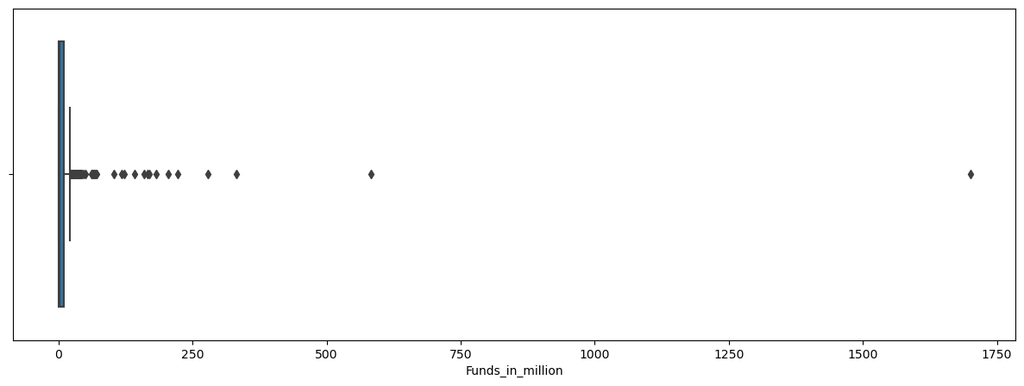

```python
plt.figure(figsize=(15,5))
sns.boxplot(data=startup,x='Funds_in_million')
plt.show()
```

- Many outliers are there which can be possible because some startups have really large funding and investments

##### D. Check the number of outliers greater than the upper fence. [1 Mark]

- Looking at the above box plot it is not very clear to know the exact number about upper fence, hence we will calculate it
- We know the formula to get upper whisker/fence = Q3 + (1.5 * IQR) where Q3 is 3rd quantile(75%), IQR(Interquartile Range) is Q3-Q1, Q1 is first quantile(25%)

```python
startup['Funds_in_million'].describe()
```

```
count     446.000000
mean       17.241489
std        90.483710
min         0.005000
25%         0.745250
50%         2.200000
75%         9.475000
max      1700.000000
Name: Funds_in_million, dtype: float64
```

```python
Q1=startup['Funds_in_million'].quantile(0.25)
Q3=startup['Funds_in_million'].quantile(0.75)
IQR=Q3-Q1
UpperFence=Q3+(1.5*IQR)
UpperFence
```

```
22.569625
```

```python
#check the count of outliers greater than upper fence
startup.loc[startup['Funds_in_million']>UpperFence]['Funds_in_million'].count()
```

```
60
```

- There are 60 outliers which are greater than upperfence value i.e 22.569625 million

##### E. Check frequency of the OperatingState features classes. [1 Mark]

```python
startup.groupby(['OperatingState'])['OperatingState'].count()
```

```
OperatingState
Acquired      66
Closed        57
Ipo            4
Operating    319
Name: OperatingState, dtype: int64
```

- There are 4 types of Operating State Closed, Operating, Acquired, Ipo
- Operating has highest frequency which is occuring 319 times
- Acquired is 2nd highest frequency occuring 66 times for OperatingState
- Closed has 3rd highest frequency occuring 57 times
- Ipo has lowest frequency occuring only 4 times.

##### 4. Statistical Analysis: [10 Marks]

##### A. Is there any significant difference between Funds raised by companies that are still operating vs companies that closed down? [1 Mark]

#### We will do hypothesis testing to get answer of this question, let us visualize this a bit for better understanding

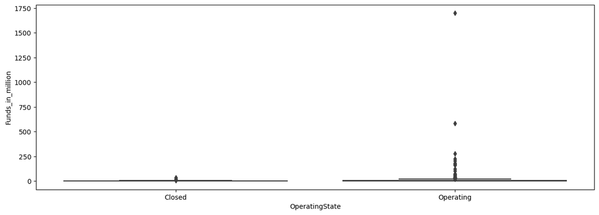

```python
startup_filter = startup.loc[(startup['OperatingState'].isin(['Operating','Closed']))]
plt.figure(figsize=(15,5))
sns.boxplot(data=startup_filter,x='OperatingState',y='Funds_in_million')
plt.show()
```

- It is not very clear to identify difference here due to a lot of outliers for operating
- we will zoom in a bit to compare the closed and operating one

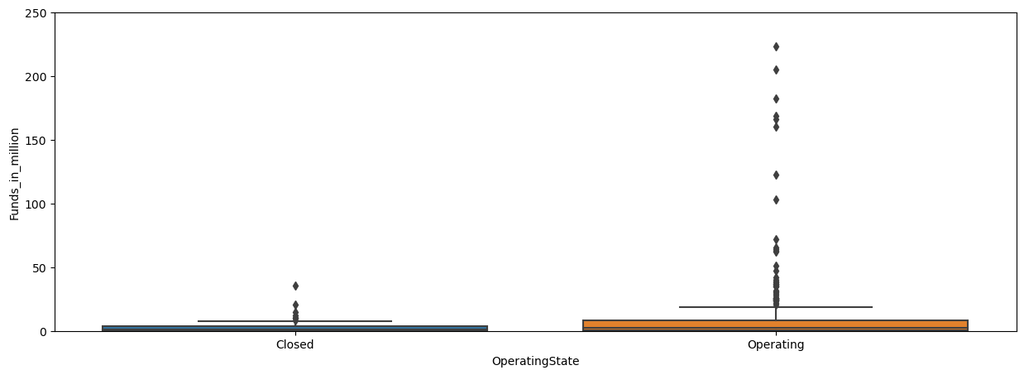

```python
plt.figure(figsize=(15,5))
sns.boxplot(data=startup_filter,x='OperatingState',y='Funds_in_million')
plt.ylim(0,250)
plt.show()
```

#### Let us to Hypothesis testing to identify the answer of this question

- 2 independent samples are given
  - first thoses startups which are closed
  - second those startups which are operating

#### Hence it would be a 2 sample independent ttest

- H0: "There is no significant difference between Funds raised by companies that are still operating vs companies that closed down"
- HA: "There is significant difference between Funds raised by companies that are still operating vs companies that closed down"

```python
import scipy.stats as stats
#Operating Startup Funds_in_million sample
OStartupFundsInMillion = startup.loc[startup['OperatingState']=='Operating']['Funds_in_million']
#Closed Startup Funds_in_million sample
CStartupFundsInMillion = startup.loc[startup['OperatingState']=='Closed']['Funds_in_million']
#Consider level of significance as 0.05
alpha=0.05
#Do 2 sample independent ttest
t_statistic, p_value = stats.ttest_ind(OStartupFundsInMillion, CStartupFundsInMillion, equal_var=True)
print('t_statistic:', t_statistic, "\np_value:",p_value)

if(p_value<alpha):
    print("There is significant difference between Funds raised by companies that are still operating vs companies that closed down")
else:
    print("There is no significant difference between Funds raised by companies that are still operating vs companies that closed down")
```

```
t_statistic: 1.1382924515740138
p_value: 0.25572701885629406
There is no significant difference between Funds raised by companies that are still operating vs companies that closed down
```

##### B. Write the null hypothesis and alternative hypothesis. [1 Mark]

#### Null Hypothesis:

**H0:** "There is no significant difference between Funds raised by companies that are still operating vs companies that closed down"

#### Alternate Hypothesis:

**HA:** "There is significant difference between Funds raised by companies that are still operating vs companies that closed down"

##### C. Test for significance and conclusion [1 Mark]

```python
import scipy.stats as stats
#Operating Startup Funds_in_million sample
OStartupFundsInMillion = startup.loc[startup['OperatingState']=='Operating']['Funds_in_million']
#Closed Startup Funds_in_million sample
CStartupFundsInMillion = startup.loc[startup['OperatingState']=='Closed']['Funds_in_million']
#Consider level of significance as 0.05
alpha=0.05
#Do 2 sample independent ttest
t_statistic, p_value = stats.ttest_ind(OStartupFundsInMillion, CStartupFundsInMillion, equal_var=True)
print('t_statistic:', t_statistic, "\np_value:",p_value)

if(p_value<alpha):
    print("There is significant difference between Funds raised by companies that are still operating vs companies that closed down")
else:
    print("There is no significant difference between Funds raised by companies that are still operating vs companies that closed down")
```

```
t_statistic: 1.1382924515740138
p_value: 0.25572701885629406
There is no significant difference between Funds raised by companies that are still operating vs companies that closed down
```

#### Conclusion:

- Since p_value is greater than alpha i.e level of significance, we fail to reject the null hypothesis which means There is **no** significant difference between funds raised by companies that are still operating vs companies that closed down.

##### D. Make a copy of the original data frame. [1 Mark]

```python
startup_copy = startup.copy() #copies the original data frame
```

```python
#Let us read the copied dataframe
startup_copy.head()
```

|  | Startup | Product | Funding | Event | Result | OperatingState | Funds_in_million |
| --- | --- | --- | --- | --- | --- | --- | --- |
| 1 | 3DLT | 3dlt.com | $630K | Disrupt NYC 2013 | Contestant | Closed | 0.63 |
| 3 | 3Dprintler | 3dprintler.com | $1M | Disrupt NY 2016 | Audience choice | Operating | 1.00 |
| 5 | 5to1 | 5to1.com | $19.3M | TC50 2009 | Contestant | Acquired | 19.30 |
| 6 | 8 Securities | 8securities.com | $29M | Disrupt Beijing 2011 | Finalist | Operating | 29.00 |
| 10 | AdhereTech | adheretech.com | $1.8M | Hardware Battlefield 2014 | Contestant | Operating | 1.80 |

##### E. Check frequency distribution of Result variables. [1 Mark]

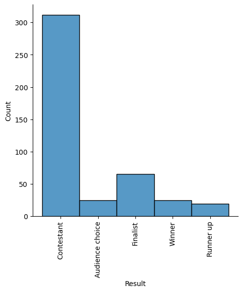

```python
sns.displot(data=startup,x='Result')
plt.xticks(rotation=90)
plt.show()
```

- Contestant has highest frequency with more than 300 occurances
- Runner up is having lowest frequency with less than 25 occurances
- Finalist frequency count is in the middle with more than 50 and less than 100 occurances

#### Let us get the exact number of occurances

```python
startup['Result'].value_counts()
```

```
Contestant         312
Finalist            65
Audience choice     25
Winner              25
Runner up           19
Name: Result, dtype: int64
```

- Contestant is occuring 312 times, Finalist 65 times, Audience choice 25 times, Winner 25 times and Runner up 19 times

##### F. Calculate percentage of winners that are still operating and percentage of contestants that are still operating [1 Mark]

```python
# List the Result with Contestant and Winner
result_filtered = startup.loc[startup['Result'].isin(['Winner','Contestant'])]['Result']
result_filtered
```

```
1      Contestant
5      Contestant
10     Contestant
11     Contestant
13         Winner
          ...
649    Contestant
650        Winner
654    Contestant
657    Contestant
659    Contestant
Name: Result, Length: 337, dtype: object
```

```python
#List the OperatingState with Operating status
operatingstate_filtered = startup.loc[startup['OperatingState']=='Operating']['OperatingState']
operatingstate_filtered
```

```
3      Operating
6      Operating
10     Operating
13     Operating
14     Operating
         ...
657    Operating
658    Operating
659    Operating
660    Operating
661    Operating
Name: OperatingState, Length: 319, dtype: object
```

```python
#Cross tabulate with percentages
startupdf = pd.crosstab(operatingstate_filtered,result_filtered,normalize='index')*100
startupdf
```

| Result OperatingState | Contestant | Winner |
| --- | --- | --- |
| Operating | 92.241379 | 7.758621 |

##### G. Write your hypothesis comparing the proportion of companies that are operating between winners and contestants: [2 Mark]

**Null Hypothesis:**  
**H0:** Proportion of operating companies is the same for both winners and contestants  
**Alternate Hypothesis:**  
**HA:** Proportion of operating companies is not the same for both winners and contestants

```python
#consider level of significance alpha as 0.05
alpha = 0.05
#Chisquare test
test_stat, pval, dof, expected_value = stats.chi2_contingency(observed = startupdf.values)
pval
```

```
1.0
```

##### H. Test for significance and conclusion [1 Mark]

```python
#Test for significance
if pval<alpha :
    print("We reject the null hpothesis i.e Proportion of operating companies is not the same for both winners and contestants")
else:
    print("We failed to reject the null hpothesis meaning Proportion of operating companies is the same for both winners and contestants")
```

```
We failed to reject the null hpothesis meaning Proportion of operating companies is the same for both winners and contestants
```

**Conclusion:**

- Since pval is greater than level of significance, We failed to reject the null hypothesis that means Yes the Proportion of operating companies is the same for both winners and contestants

##### I. Select only the Event that has ‘disrupt’ keyword from 2013 onwards. [1 Mark]

```python
startup['Event'].unique()
```

```
array(['Disrupt NYC 2013', 'Disrupt NY 2016', 'TC50 2009',
       'Disrupt Beijing 2011', 'Hardware Battlefield 2014', 'TC50 2008',
       'Disrupt SF 2015', 'Disrupt London 2016', 'Disrupt NYC 2014',
       'Disrupt SF 2012', 'Disrupt SF 2011', 'TC40 2007',
       'Disrupt NYC 2010', 'Disrupt NYC 2012', 'Disrupt EU 2013',
       'Disrupt NYC 2011', 'Disrupt SF 2010', 'Disrupt SF 2014',
       'Disrupt SF 2013', 'Disrupt NY 2015', 'Disrupt SF 2016', '-',
       'Hardware Battlefield 2015', 'Hardware Battlefield 2016',
       'Disrupt London 2015', 'Disrupt EU 2014'], dtype=object)
```

- All the event values have Year in it as last 4 characters except one event that has - value
- We can extract Year column out of this

```python
startup['Event'].value_counts()
```

```
TC50 2008                    31
TC40 2007                    30
TC50 2009                    26
Disrupt SF 2011              24
Disrupt NYC 2013             22
                             ..
Hardware Battlefield 2015    10
Disrupt EU 2014              10
Disrupt EU 2013               9
Disrupt Beijing 2011          7
-                             6
Name: Event, Length: 26, dtype: int64
```

- We see TC50 2008 is the highest frequency data which has come 31 times
- So we have 2 option either to drop this row or replace - with highest frequency value. but, dropping will also depend upon how many such rows are there with event as hyphen value, if it is big number we should replace with some value.
- Let us see the data with event as - and find out some pattern

```python
startup.loc[startup['Event']=='-']
```

|  | Startup | Product | Funding | Event | Result | OperatingState | Funds_in_million |
| --- | --- | --- | --- | --- | --- | --- | --- |
| 68 | Bloomlife | bloomlife.com | $4M | - | Runner up | Operating | 4.0000 |
| 292 | Knocki | knocki.com | $1.9M | - | Audience choice | Operating | 1.9000 |
| 416 | Pillar Technologies | pillar.tech | $525K | - | Finalist | Operating | 0.5250 |
| 500 | Siren Care | siren.care | $129.8K | - | Winner | Operating | 0.1298 |
| 611 | Venneos GmbH | venneos.com | $1.1M | - | Contestant | Operating | 1.1000 |
| 658 | Zmorph | zmorph3d.com | $1M | - | Audience choice | Operating | 1.0000 |

- Total 6 rows are their with - value, they are all Operating
- Let us find the frequency of event for operating state company

```python
startup.loc[startup['OperatingState']=='Operating']['Event'].value_counts()
```

```
Disrupt NY 2015         20
Disrupt SF 2015         19
Disrupt SF 2013         18
Disrupt SF 2014         18
Disrupt NYC 2012        17
                        ..
TC50 2009                9
Disrupt EU 2013          8
Disrupt SF 2010          8
-                        6
Disrupt Beijing 2011     5
Name: Event, Length: 26, dtype: int64
```

- So we find that Disrupt NY 2015 event is having highest frequency, so we will replace - value with Disrupt NY 2015

```python
startup['Event']=startup['Event'].replace('-','Disrupt NY 2015')
#Let us see now if any value with -
startup.loc[startup['Event']=='-']
```

|  | Startup | Product | Funding | Event | Result | OperatingState | Funds_in_million |
| --- | --- | --- | --- | --- | --- | --- | --- |

- - Values are replaced

```python
#Extract a year column out of the event column
startup['Year'] = startup['Event'].str[-4:].astype(int)
```

```python
startup.head()
```

|  | Startup | Product | Funding | Event | Result | OperatingState | Funds_in_million | Year |
| --- | --- | --- | --- | --- | --- | --- | --- | --- |
| 1 | 3DLT | 3dlt.com | $630K | Disrupt NYC 2013 | Contestant | Closed | 0.63 | 2013 |
| 3 | 3Dprintler | 3dprintler.com | $1M | Disrupt NY 2016 | Audience choice | Operating | 1.00 | 2016 |
| 5 | 5to1 | 5to1.com | $19.3M | TC50 2009 | Contestant | Acquired | 19.30 | 2009 |
| 6 | 8 Securities | 8securities.com | $29M | Disrupt Beijing 2011 | Finalist | Operating | 29.00 | 2011 |
| 10 | AdhereTech | adheretech.com | $1.8M | Hardware Battlefield 2014 | Contestant | Operating | 1.80 | 2014 |

```python
#Here is the events with disrupt keyword
startup.loc[(startup['Event'].str.contains('disrupt',case=False)) & (startup['Year']>=2013)]
```

|  | Startup | Product | Funding | Event | Result | OperatingState | Funds_in_million | Year |
| --- | --- | --- | --- | --- | --- | --- | --- | --- |
| 1 | 3DLT | 3dlt.com | $630K | Disrupt NYC 2013 | Contestant | Closed | 0.630 | 2013 |
| 3 | 3Dprintler | 3dprintler.com | $1M | Disrupt NY 2016 | Audience choice | Operating | 1.000 | 2016 |
| 13 | Agrilyst | agrilyst.com | $1M | Disrupt SF 2015 | Winner | Operating | 1.000 | 2015 |
| 14 | Aiden | aiden.ai | $750K | Disrupt London 2016 | Contestant | Operating | 0.750 | 2016 |
| 16 | Aircall | aircall.io | $11.6M | Disrupt SF 2015 | Contestant | Operating | 11.600 | 2015 |
| ... | ... | ... | ... | ... | ... | ... | ... | ... |
| 642 | Xendo | xendo.com | $28K | Disrupt SF 2014 | Contestant | Acquired | 0.028 | 2014 |
| 646 | YayPay Inc | yaypay.com | $900K | Disrupt London 2015 | Contestant | Operating | 0.900 | 2015 |
| 656 | Zenefits | zenefits.com | $583.6M | Disrupt NYC 2013 | Finalist | Operating | 583.600 | 2013 |
| 658 | Zmorph | zmorph3d.com | $1M | Disrupt NY 2015 | Audience choice | Operating | 1.000 | 2015 |
| 660 | Zula | zulaapp.com | $3.4M | Disrupt SF 2013 | Audience choice | Operating | 3.400 | 2013 |

199 rows × 8 columns

- We can see there are total 199 events that has disrupt keyword from 2013 onwards